# Analysis of proteomic data from EF1 degron

This document details the analysis of proteomics data acquired to look at protein expression in dTAG labeled EWS-FLI1 expressing EWS502 cells from PMID32948771.

## Setting up the environment

These are packages you will need for this notebook. For exact versions used, please refer to the session info at the bottom of this notebook.

```r
##########################################################################################
library('tidyverse')
library('ggplot2')
library('RColorBrewer')
library('limma')
library('DEqMS')
library('matrixStats')
library('ggrepel')
library('DESeq2')
```

I want to set a base directory that we can use as a link to the directory where we will do most of the work. I use two directories here because the Workspace is what is pushed to GitHub and contains scripts and plot files, but the Repository is where more of the big data is stored that does not get pushed.

```r
##########################################################################################
generalDatasets = 'C:/Users/chughes/Documents/bccrc/projectsRepository/generalDatasets'
baseWorkspace = 'C:/Users/chughes/Documents/bccrc/projectsWorkspace/sorensenLab/relatedToDlg2'
baseRepository = 'C:/Users/chughes/Documents/bccrc/projectsRepository/sorensenLab/relatedToDlg2'
#generalDatasets = 'C:/Users/chris/OneDrive/Documents/bccrc/projectsRepository/generalDatasets'
#baseWorkspace = 'C:/Users/chris/OneDrive/Documents/bccrc/projectsWorkspace/sorensenLab/relatedToYbx1'
#baseRepository = 'C:/Users/chris/OneDrive/Documents/bccrc/projectsRepository/sorensenLab/relatedToYbx1'
```

## Data processing

Read in the peptide spectral match data.

```r
##########################################################################################
#identification data
psmData = read_tsv(paste(baseRepository, '/proteomics20210930_ewsDtagPtxPmid32948771/psm.tsv', sep = '')) %>%
  dplyr::select(Spectrum, `Modified Peptide`, `Protein ID`, Gene, `Is Unique`) %>%
  dplyr::rename(sequence = `Modified Peptide`,
                accession = `Protein ID`,
                gene = Gene,
                unique = `Is Unique`) %>%
  dplyr::mutate(scan = as.numeric(sub('.*_f[0-9]+\\.(.*)\\.[0-9]+\\.[0-9]+$', '\\1', Spectrum))) %>%
  dplyr::mutate(fraction = sub('.*dTAG_(.*)\\.[0-9]+\\.[0-9]+\\.[0-9]+$', '\\1', Spectrum)) %>%
  #dplyr::filter(unique == TRUE) %>%
  dplyr::select(scan, fraction, accession, gene, sequence)
#quant data
processQuant = function(rawToolsFile, ...){
  quantIn = read_tsv(rawToolsFile) %>%
    dplyr::select(MS2ScanNumber, ParentPeakArea, `126Intensity`:`131CIntensity`) %>%
    dplyr::rename(scan = MS2ScanNumber,
                  dmso_1 = `126Intensity`,
                  dmso_2 = `127NIntensity`,
                  t2h_1 = `127CIntensity`,
                  t2h_2 = `128NIntensity`,
                  t2h_3 = `128CIntensity`,
                  t6h_1 = `129NIntensity`,
                  t6h_2 = `129CIntensity`,
                  t6h_3 = `130NIntensity`,
                  t24h_1 = `130CIntensity`,
                  t24h_2 = `131NIntensity`,
                  t24h_3 = `131CIntensity`) %>%
    dplyr::mutate(fraction = sub('.*dTAG_(.*)\\.raw_Matrix.txt', '\\1', rawToolsFile))
  return(quantIn)
}
#
quantFileList = list.files(paste(baseRepository, '/proteomics20210930_ewsDtagPtxPmid32948771/quantFiles/', sep = ''), full.names = TRUE, pattern = '_Matrix.txt')
quantData = do.call('rbind', lapply(quantFileList, processQuant))
```

[output not shown]

[output not shown]

[output not shown]

[output not shown]

[output not shown]

[output not shown]

[output not shown]

[output not shown]

[output not shown]

[output not shown]

[output not shown]

```r
#combine the files
psmQuant = psmData %>%
  left_join(quantData) %>%
  dplyr::select(accession:t24h_3) %>%
  dplyr::rowwise(sequence, accession, gene) %>%
  dplyr::mutate(totalSignal = sum(c_across(dmso_1:t24h_3), na.rm = TRUE)) %>%
  dplyr::filter(totalSignal >= 1000, !is.na(sequence), !is.na(gene))
dlg2 = psmQuant[grepl('DLG2', psmQuant$gene),]
psmQuant
```

| accession | gene | sequence | ParentPeakArea | dmso_1 | dmso_2 | t2h_1 | t2h_2 | t2h_3 | t6h_1 | t6h_2 | t6h_3 | t24h_1 | t24h_2 | t24h_3 | totalSignal |
| --- | --- | --- | --- | --- | --- | --- | --- | --- | --- | --- | --- | --- | --- | --- | --- |
| P52272 | HNRNPM | n[230]EDPDGEHAR | 3.852894e+07 | 1.299531e+05 | 1.331511e+05 | 8.896389e+04 | 7.944005e+04 | 8.723277e+04 | 1.104035e+05 | 1.255599e+05 | 1.170375e+05 | 1.157498e+05 | 1.125428e+05 | 1.149327e+05 | 1.214967e+06 |
| P06753 | TPM3 | n[230]AADESER | 6.201728e+05 | 1.807492e+04 | 1.670908e+04 | 2.607588e+04 | 2.453011e+04 | 2.386072e+04 | 1.432088e+04 | 1.819187e+04 | 1.592796e+04 | 1.371403e+04 | 1.234455e+04 | 1.150563e+04 | 1.952556e+05 |
| Q9NR28 | DIABLO | n[230]TQEEGEER | 7.827237e+06 | 2.012844e+04 | 2.431083e+04 | 1.513219e+04 | 1.157065e+04 | 1.396081e+04 | 1.905118e+04 | 1.944458e+04 | 1.742548e+04 | 1.833984e+04 | 2.041359e+04 | 1.942736e+04 | 1.992049e+05 |
| Q14103 | HNRNPD | n[230]NEEDEGHSNSSPR | 1.752857e+06 | 1.330643e+04 | 2.399905e+04 | 1.004164e+04 | 9.297574e+03 | 1.035349e+04 | 1.203809e+04 | 1.592692e+04 | 1.151813e+04 | 1.580808e+04 | 1.749489e+04 | 1.211970e+04 | 1.519040e+05 |
| Q14966 | ZNF638 | n[230]EQNEAEER | 1.889654e+06 | 3.563796e+03 | 7.583513e+03 | 3.807074e+03 | 3.990378e+03 | 5.170651e+03 | 3.730216e+03 | 4.935102e+03 | 5.797655e+03 | 4.270396e+03 | 5.665960e+03 | 4.653315e+03 | 5.316806e+04 |
| Q9H089 | LSG1 | n[230]ESSTADSEAR | 3.271165e+06 | 3.726339e+03 | 5.714214e+03 | 4.598861e+03 | 3.965516e+03 | 4.510330e+03 | 4.926618e+03 | 5.784881e+03 | 3.884680e+03 | 3.646474e+03 | 2.808307e+03 | 5.283273e+03 | 4.884949e+04 |
| P08243 | ASNS | n[230]AEEESER | 7.896283e+05 | 2.494420e+03 | 1.737572e+03 | 4.168176e+03 | 2.884794e+03 | 3.744208e+03 | 2.420289e+03 | 2.661813e+03 | 2.711594e+03 | 7.793259e+02 | 1.624551e+03 | 1.482356e+03 | 2.670910e+04 |
| P15311 | EZR | n[230]AQEEAER | 1.936819e+06 | 2.324228e+03 | 3.400854e+03 | 2.757505e+03 | 2.413283e+03 | 2.533939e+03 | 1.810521e+03 | 2.278434e+03 | 3.335432e+03 | 2.082288e+03 | 2.293319e+03 | 1.823605e+03 | 2.705341e+04 |
| Q53GS9 | USP39 | n[230]DNDETNQQGA | 2.162297e+06 | 3.211306e+03 | 2.508854e+03 | 2.786892e+03 | 1.975967e+03 | 1.771811e+03 | 2.162985e+03 | 2.720738e+03 | 2.505583e+03 | 1.652031e+03 | 2.062455e+03 | 2.828242e+03 | 2.618686e+04 |
| Q9BUQ8 | DDX23 | n[230]ETNGNEDEEGR | 2.228193e+06 | 2.716416e+03 | 2.550744e+03 | 1.927393e+03 | 1.765298e+03 | 1.773057e+03 | 2.288819e+03 | 2.777094e+03 | 2.433387e+03 | 1.757741e+03 | 1.848638e+03 | 2.175175e+03 | 2.401376e+04 |

[output cut: 990 more lines]

For some reason fraction 12 is missing. It looks like the RawTools run threw an error for some reason, will need to go back and check this. Now do a DEQ analysis.

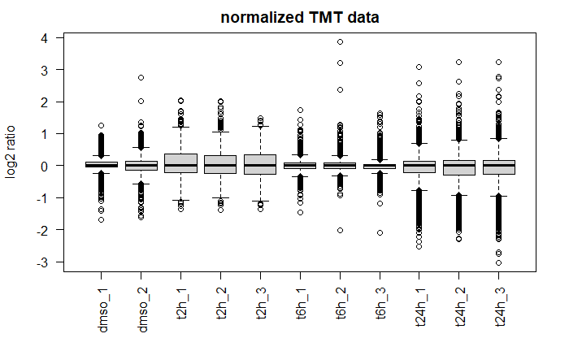

```r
##########################################################################################
quantInput = psmQuant[,c(3,2,5:15)] #sequence then gene
saveRDS(quantInput, paste(baseRepository, '/proteomics20210930_ewsDtagPtxPmid32948771/dataset_peptideQuantDataPreDEqMS.rds', sep = ''))
quantInputLog = quantInput
quantInputLog[,3:13][quantInputLog[,3:13] == 0] = NA
quantInputLog[,3:13] = log2(quantInputLog[,3:13])
quantInputNormalized = medianSweeping(quantInputLog, group_col = 2)
boxplot(quantInputNormalized, las = 2, ylab = 'log2 ratio', main = 'normalized TMT data')
```

```r
##########################################################################################
cond = as.factor(c('dmso','dmso','t2h','t2h','t2h','t6h','t6h','t6h','t24h','t24h','t24h'))
design = model.matrix(~0+cond)
colnames(design) = gsub('cond', '', colnames(design))
```

Now we can build the Limma model.

```r
##########################################################################################
geneMatrix = as.matrix(quantInputNormalized)
limmaFit1 = lmFit(geneMatrix, design)
limmaContrasts = c('t2h - dmso', 't6h - dmso', 't24h - dmso')
limmaContrastDesign =  makeContrasts(contrasts = limmaContrasts, levels = design)
limmaFit2 = eBayes(contrasts.fit(limmaFit1, contrasts = limmaContrastDesign))
```

```r
##########################################################################################
psmCountTable = as.data.frame(table(quantInput$gene))
rownames(psmCountTable) = psmCountTable$Var1
limmaFit2$count = psmCountTable[rownames(limmaFit2$coefficients),2]
limmaFit3 = spectraCounteBayes(limmaFit2)
head(limmaFit3$coefficients)
```

```
       Contrasts
         t2h - dmso   t6h - dmso  t24h - dmso
  A1BG   1.70664553  0.357046981  0.153273389
  A2M    0.55412952  0.007849380  0.418104894
  AAAS  -0.07579281  0.089900465 -0.008953643
  AACS   0.85812310  0.108965700  0.060752356
  AAGAB  0.91679064  0.267271366 -0.124037585
  AAMDC  0.50959411 -0.009569162  0.303472498
```

```r
##
deqmsResults = outputResult(limmaFit3, coef_col = 3)
dim(deqmsResults)
```

```
[1] 8107   11
```

```r
saveRDS(deqmsResults, paste(baseRepository, '/proteomics20210930_ewsDtagPtxPmid32948771/dataset_deqms_t24h-dmso.rds', sep = ''))
write.table(deqmsResults,
            paste(baseRepository, '/proteomics20210930_ewsDtagPtxPmid32948771/dataset_deqms_t24h-dmso.csv', sep = ''),
            sep = ',', row.names = FALSE, quote = FALSE)

deqmsResults = outputResult(limmaFit3, coef_col = 2)
dim(deqmsResults)
```

```
[1] 8107   11
```

```r
saveRDS(deqmsResults, paste(baseRepository, '/proteomics20210930_ewsDtagPtxPmid32948771/dataset_deqms_t6h-dmso.rds', sep = ''))
write.table(deqmsResults,
            paste(baseRepository, '/proteomics20210930_ewsDtagPtxPmid32948771/dataset_deqms_t6h-dmso.csv', sep = ''),
            sep = ',', row.names = FALSE, quote = FALSE)
```

Now let us make a volcano plot to show the data.

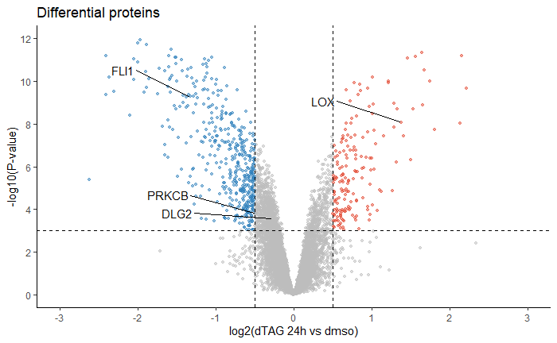

```r
##########################################################################################
deqmsResults = outputResult(limmaFit3, coef_col = 3)
deqmsResults$plotPValue = -log10(deqmsResults$sca.P.Value)
deqmsResults$pColors = ifelse(deqmsResults$logFC <= -0.5 & deqmsResults$plotPValue >= 3, brewer.pal(3,'Blues')[3],
                              ifelse(deqmsResults$logFC >= 0.5 & deqmsResults$plotPValue >= 3, brewer.pal(3,'OrRd')[3],
                                     brewer.pal(3,'Greys')[2]))
#
goi = c('PRKCB','LOX','DLG2','FLI1')
deqmsResults$pText = ifelse(deqmsResults$gene %in% goi, deqmsResults$gene, '')
##
ggplot(deqmsResults, aes(logFC, plotPValue)) +
  geom_point(size = 1, color = deqmsResults$pColors, alpha = 0.5) +
  geom_text_repel(label = deqmsResults$pText, nudge_x = -1, nudge_y = 1, max.overlaps = 10000) +
  labs(x = 'log2(dTAG 24h vs dmso)', y = '-log10(P-value)', title = 'Differential proteins') +
  scale_y_continuous(limits = c(0,12), breaks = seq(0,20,2)) +
  scale_x_continuous(limits = c(-3,3), breaks = seq(-6,6,1)) +
  geom_vline(xintercept = c(-0.5,0.5), linetype = 'dashed') +
  geom_hline(yintercept = 3, linetype = 'dashed') +
  theme_classic()
ggsave(paste(baseRepository, '/proteomics20210930_ewsDtagPtxPmid32948771/scatter_deqms_t24h-dmso.pdf', sep = ''),
       height = 2, width = 2, useDingbats = FALSE)
```

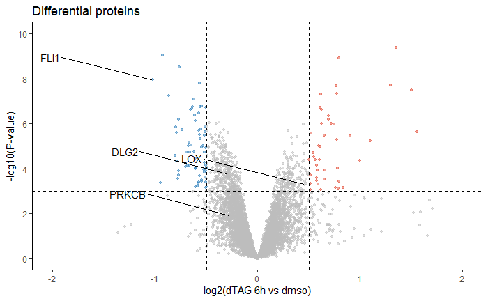

```r
##########################################################################################
deqmsResults = outputResult(limmaFit3, coef_col = 2)
deqmsResults$plotPValue = -log10(deqmsResults$sca.P.Value)
deqmsResults$pColors = ifelse(deqmsResults$logFC <= -0.5 & deqmsResults$plotPValue >= 3, brewer.pal(3,'Blues')[3],
                              ifelse(deqmsResults$logFC >= 0.5 & deqmsResults$plotPValue >= 3, brewer.pal(3,'OrRd')[3],
                                     brewer.pal(3,'Greys')[2]))
#
goi = c('PRKCB','LOX','DLG2','FLI1')
deqmsResults$pText = ifelse(deqmsResults$gene %in% goi, deqmsResults$gene, '')
##
ggplot(deqmsResults, aes(logFC, plotPValue)) +
  geom_point(size = 1, color = deqmsResults$pColors, alpha = 0.5) +
  geom_text_repel(label = deqmsResults$pText, nudge_x = -1, nudge_y = 1, max.overlaps = 10000) +
  labs(x = 'log2(dTAG 6h vs dmso)', y = '-log10(P-value)', title = 'Differential proteins') +
  scale_y_continuous(limits = c(0,10), breaks = seq(0,20,2)) +
  scale_x_continuous(limits = c(-2,2), breaks = seq(-6,6,1)) +
  geom_vline(xintercept = c(-0.5,0.5), linetype = 'dashed') +
  geom_hline(yintercept = 3, linetype = 'dashed') +
  theme_classic()
ggsave(paste(baseRepository, '/proteomics20210930_ewsDtagPtxPmid32948771/scatter_deqms_t6h-dmso.pdf', sep = ''),
       height = 2, width = 2, useDingbats = FALSE)
```

## Session info

````r
```r
##########################################################################################
sessionInfo()
````

R version 4.0.2 (2020-06-22) Platform: x86_64-w64-mingw32/x64 (64-bit) Running under: Windows 10 x64 (build 19042)

Matrix products: default

locale: [1] LC_COLLATE=English_Canada.1252 LC_CTYPE=English_Canada.1252 LC_MONETARY=English_Canada.1252 LC_NUMERIC=C LC_TIME=English_Canada.1252

attached base packages: [1] parallel stats4 stats graphics grDevices utils datasets methods base

other attached packages: [1] DESeq2_1.28.1 SummarizedExperiment_1.18.2 DelayedArray_0.14.1 Biobase_2.48.0 GenomicRanges_1.40.0  
[6] GenomeInfoDb_1.24.2 IRanges_2.22.2 S4Vectors_0.26.1 BiocGenerics_0.34.0 ggrepel_0.9.1  
[11] matrixStats_0.58.0 DEqMS_1.6.0 limma_3.44.3 RColorBrewer_1.1-2 forcats_0.5.1  
[16] stringr_1.4.0 dplyr_1.0.5 purrr_0.3.4 readr_1.4.0 tidyr_1.1.3  
[21] tibble_3.1.1 ggplot2_3.3.3 tidyverse_1.3.1

loaded via a namespace (and not attached): [1] bitops_1.0-7 fs_1.5.0 lubridate_1.7.10 bit64_4.0.5 httr_1.4.2 bslib_0.2.4 tools_4.0.2  
[8] backports_1.2.1 utf8_1.2.1 R6_2.5.0 DBI_1.1.1 colorspace_2.0-0 withr_2.4.2 tidyselect_1.1.0  
[15] bit_4.0.4 compiler_4.0.2 cli_2.5.0 rvest_1.0.0 xml2_1.3.2 labeling_0.4.2 sass_0.3.1  
[22] scales_1.1.1 genefilter_1.70.0 digest_0.6.27 rmarkdown_2.7 XVector_0.28.0 pkgconfig_2.0.3 htmltools_0.5.1.1  
[29] fastmap_1.1.0 dbplyr_2.1.1 rlang_0.4.10 readxl_1.3.1 rstudioapi_0.13 RSQLite_2.2.7 farver_2.1.0  
[36] jquerylib_0.1.4 generics_0.1.0 jsonlite_1.7.2 BiocParallel_1.22.0 RCurl_1.98-1.3 magrittr_2.0.1 GenomeInfoDbData_1.2.3 [43] Matrix_1.2-18 Rcpp_1.0.6 munsell_0.5.0 fansi_0.4.2 lifecycle_1.0.0 stringi_1.5.3 yaml_2.2.1  
[50] zlibbioc_1.34.0 plyr_1.8.6 grid_4.0.2 blob_1.2.1 crayon_1.4.1 lattice_0.20-41 splines_4.0.2  
[57] haven_2.4.1 annotate_1.66.0 hms_1.0.0 locfit_1.5-9.4 knitr_1.33 pillar_1.6.0 geneplotter_1.66.0  
[64] reprex_2.0.0 XML_3.99-0.6 glue_1.4.2 evaluate_0.14 modelr_0.1.8 vctrs_0.3.7 cellranger_1.1.0  
[71] gtable_0.3.0 assertthat_0.2.1 cachem_1.0.4 xfun_0.22 xtable_1.8-4 broom_0.7.6 survival_3.2-11  
[78] AnnotationDbi_1.50.3 memoise_2.0.0 ellipsis_0.3.1  
```